# Chapter 4 - Clustering and classification

## Overview of the data

Let’s download the data for this exercise.

```r
library(MASS)
data("Boston")
```

The Boston dataset is titled “Housing Values in Suburbs of Boston” so the dataset includes information on variables which influence these values.

```r
library(dplyr)
glimpse(Boston)
```

```
## Rows: 506
## Columns: 14
## $ crim    <dbl> 0.00632, 0.02731, 0.02729, 0.03237, 0.06905, 0.02985, 0.08829…
## $ zn      <dbl> 18.0, 0.0, 0.0, 0.0, 0.0, 0.0, 12.5, 12.5, 12.5, 12.5, 12.5, …
## $ indus   <dbl> 2.31, 7.07, 7.07, 2.18, 2.18, 2.18, 7.87, 7.87, 7.87, 7.87, 7…
## $ chas    <int> 0, 0, 0, 0, 0, 0, 0, 0, 0, 0, 0, 0, 0, 0, 0, 0, 0, 0, 0, 0, 0…
## $ nox     <dbl> 0.538, 0.469, 0.469, 0.458, 0.458, 0.458, 0.524, 0.524, 0.524…
## $ rm      <dbl> 6.575, 6.421, 7.185, 6.998, 7.147, 6.430, 6.012, 6.172, 5.631…
## $ age     <dbl> 65.2, 78.9, 61.1, 45.8, 54.2, 58.7, 66.6, 96.1, 100.0, 85.9, …
## $ dis     <dbl> 4.0900, 4.9671, 4.9671, 6.0622, 6.0622, 6.0622, 5.5605, 5.950…
## $ rad     <int> 1, 2, 2, 3, 3, 3, 5, 5, 5, 5, 5, 5, 5, 4, 4, 4, 4, 4, 4, 4, 4…
## $ tax     <dbl> 296, 242, 242, 222, 222, 222, 311, 311, 311, 311, 311, 311, 3…
## $ ptratio <dbl> 15.3, 17.8, 17.8, 18.7, 18.7, 18.7, 15.2, 15.2, 15.2, 15.2, 1…
## $ black   <dbl> 396.90, 396.90, 392.83, 394.63, 396.90, 394.12, 395.60, 396.9…
## $ lstat   <dbl> 4.98, 9.14, 4.03, 2.94, 5.33, 5.21, 12.43, 19.15, 29.93, 17.1…
## $ medv    <dbl> 24.0, 21.6, 34.7, 33.4, 36.2, 28.7, 22.9, 27.1, 16.5, 18.9, 1…
```

The dataset has 14 columns and 506 observations. These columns include things like

- Crime rate (crim) per capita
- Proportion of residential land zoned (zn) for lots over 25,000 sq.ft. (whatever that converts to, Imperial units suck)
- Nitrogen oxides concentration (nx), parts per million
- Proportion of owner-occupied units built prior to 1940 (age)
- Weighed means of distances (dis) to five Boston employment centres
- Full-value propery-tax rate per $10,000 (tax)

And so on. Let’s look at some data summaries.

```r
library(ggplot2);library(GGally)
summary(Boston)
```

```
##       crim                zn             indus            chas
##  Min.   : 0.00632   Min.   :  0.00   Min.   : 0.46   Min.   :0.00000
##  1st Qu.: 0.08204   1st Qu.:  0.00   1st Qu.: 5.19   1st Qu.:0.00000
##  Median : 0.25651   Median :  0.00   Median : 9.69   Median :0.00000
##  Mean   : 3.61352   Mean   : 11.36   Mean   :11.14   Mean   :0.06917
##  3rd Qu.: 3.67708   3rd Qu.: 12.50   3rd Qu.:18.10   3rd Qu.:0.00000
##  Max.   :88.97620   Max.   :100.00   Max.   :27.74   Max.   :1.00000
##       nox               rm             age              dis
##  Min.   :0.3850   Min.   :3.561   Min.   :  2.90   Min.   : 1.130
##  1st Qu.:0.4490   1st Qu.:5.886   1st Qu.: 45.02   1st Qu.: 2.100
##  Median :0.5380   Median :6.208   Median : 77.50   Median : 3.207
##  Mean   :0.5547   Mean   :6.285   Mean   : 68.57   Mean   : 3.795
##  3rd Qu.:0.6240   3rd Qu.:6.623   3rd Qu.: 94.08   3rd Qu.: 5.188
##  Max.   :0.8710   Max.   :8.780   Max.   :100.00   Max.   :12.127
##       rad              tax           ptratio          black
##  Min.   : 1.000   Min.   :187.0   Min.   :12.60   Min.   :  0.32
##  1st Qu.: 4.000   1st Qu.:279.0   1st Qu.:17.40   1st Qu.:375.38
##  Median : 5.000   Median :330.0   Median :19.05   Median :391.44
##  Mean   : 9.549   Mean   :408.2   Mean   :18.46   Mean   :356.67
##  3rd Qu.:24.000   3rd Qu.:666.0   3rd Qu.:20.20   3rd Qu.:396.23
##  Max.   :24.000   Max.   :711.0   Max.   :22.00   Max.   :396.90
##      lstat            medv
##  Min.   : 1.73   Min.   : 5.00
##  1st Qu.: 6.95   1st Qu.:17.02
##  Median :11.36   Median :21.20
##  Mean   :12.65   Mean   :22.53
##  3rd Qu.:16.95   3rd Qu.:25.00
##  Max.   :37.97   Max.   :50.00
```

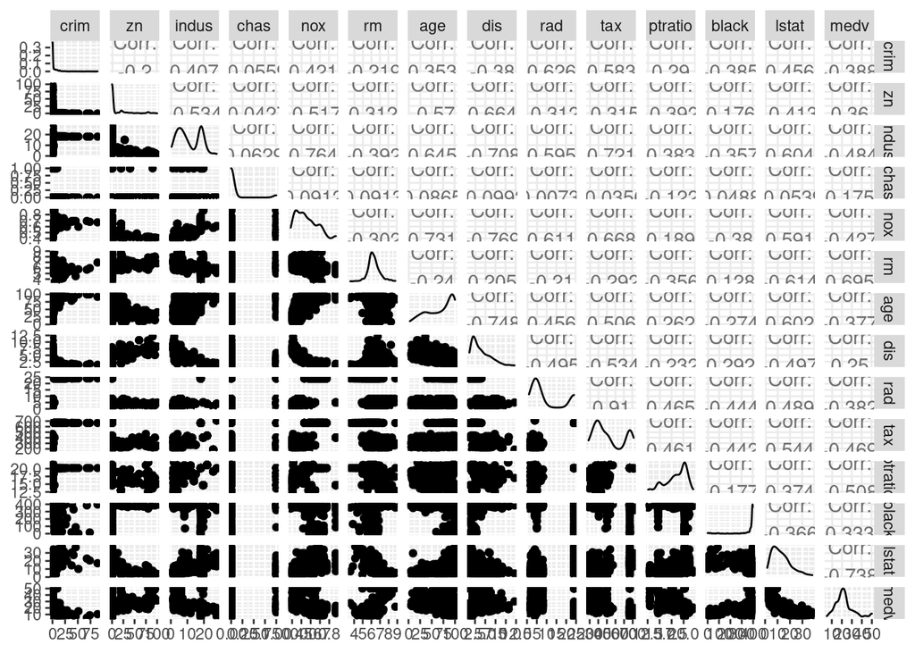

```r
ggpairs(Boston, upper = list(continuous = "cor_v1_5"))
```

## Scaling the data

We’ll scale the data by subtracting the column means from the corresponding columns and divide the difference with standard deviation. It’s simple to perform with the scale function.

```r
Boston_scaled <- scale(Boston)

# New summaries of the data after converting to data frame
Boston_scaled <- as.data.frame(Boston_scaled)
summary(Boston_scaled)
```

```
##       crim                 zn               indus              chas
##  Min.   :-0.419367   Min.   :-0.48724   Min.   :-1.5563   Min.   :-0.2723
##  1st Qu.:-0.410563   1st Qu.:-0.48724   1st Qu.:-0.8668   1st Qu.:-0.2723
##  Median :-0.390280   Median :-0.48724   Median :-0.2109   Median :-0.2723
##  Mean   : 0.000000   Mean   : 0.00000   Mean   : 0.0000   Mean   : 0.0000
##  3rd Qu.: 0.007389   3rd Qu.: 0.04872   3rd Qu.: 1.0150   3rd Qu.:-0.2723
##  Max.   : 9.924110   Max.   : 3.80047   Max.   : 2.4202   Max.   : 3.6648
##       nox                rm               age               dis
##  Min.   :-1.4644   Min.   :-3.8764   Min.   :-2.3331   Min.   :-1.2658
##  1st Qu.:-0.9121   1st Qu.:-0.5681   1st Qu.:-0.8366   1st Qu.:-0.8049
##  Median :-0.1441   Median :-0.1084   Median : 0.3171   Median :-0.2790
##  Mean   : 0.0000   Mean   : 0.0000   Mean   : 0.0000   Mean   : 0.0000
##  3rd Qu.: 0.5981   3rd Qu.: 0.4823   3rd Qu.: 0.9059   3rd Qu.: 0.6617
##  Max.   : 2.7296   Max.   : 3.5515   Max.   : 1.1164   Max.   : 3.9566
##       rad               tax             ptratio            black
##  Min.   :-0.9819   Min.   :-1.3127   Min.   :-2.7047   Min.   :-3.9033
##  1st Qu.:-0.6373   1st Qu.:-0.7668   1st Qu.:-0.4876   1st Qu.: 0.2049
##  Median :-0.5225   Median :-0.4642   Median : 0.2746   Median : 0.3808
##  Mean   : 0.0000   Mean   : 0.0000   Mean   : 0.0000   Mean   : 0.0000
##  3rd Qu.: 1.6596   3rd Qu.: 1.5294   3rd Qu.: 0.8058   3rd Qu.: 0.4332
##  Max.   : 1.6596   Max.   : 1.7964   Max.   : 1.6372   Max.   : 0.4406
##      lstat              medv
##  Min.   :-1.5296   Min.   :-1.9063
##  1st Qu.:-0.7986   1st Qu.:-0.5989
##  Median :-0.1811   Median :-0.1449
##  Mean   : 0.0000   Mean   : 0.0000
##  3rd Qu.: 0.6024   3rd Qu.: 0.2683
##  Max.   : 3.5453   Max.   : 2.9865
```

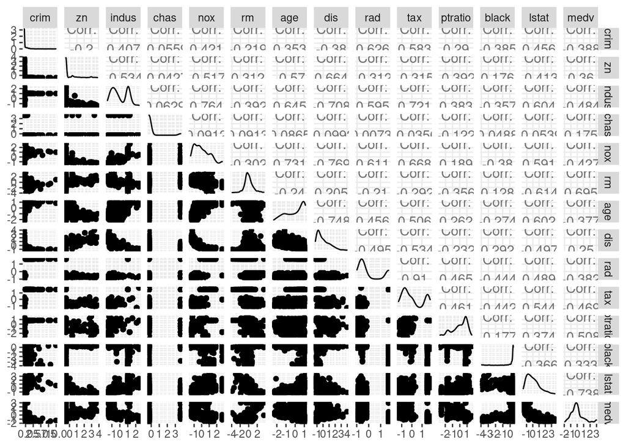

```r
ggpairs(Boston_scaled, upper = list(continuous = "cor_v1_5"))
```

The distributions didn’t change but scaling changed the units. Next we’ll create a categorical variable of crime rate.

```r
# Creating a quantile vector
quantiles <- quantile(Boston_scaled$crim)

# Creating the categorical variable
crime <- cut(Boston_scaled$crim, breaks = quantiles, include.lowest = TRUE, label = c("low", "med_low", "med_high", "high"))
table(crime)
```

```
## crime
##      low  med_low med_high     high
##      127      126      126      127
```

Looks good. We’ll add this new crime variable to the dataset and remove the old one.

```r
# Remove crim from the dataset
Boston_scaled <- dplyr::select(Boston_scaled, -crim)

# Add crime
Boston_scaled <- data.frame(Boston_scaled, crime)
```

Next we’ll create a test and training set. We’ll choose 80 % of the data for the training set, so that the remaining 20 % fall to the test set.

```r
# Randomly choose 80% of the scaled Boston rows
ind <- sample(nrow(Boston_scaled),  size = nrow(Boston_scaled) * 0.8)

# Create a training set
train <- Boston_scaled[ind,]

# Create a test set
test <- Boston_scaled[-ind,]
```

## Linear discriminant analysis

Next we’ll fit a linear discriminant analysis on the training set. For the sake of simplicity, we’ll run with two dimensions.

```r
lda_model <- lda(crime ~ ., data = train)
lda_model
```

```
## Call:
## lda(crime ~ ., data = train)
##
## Prior probabilities of groups:
##       low   med_low  med_high      high
## 0.2549505 0.2351485 0.2500000 0.2599010
##
## Group means:
##                  zn       indus        chas        nox         rm        age
## low       0.8864933 -0.88264049 -0.11943197 -0.8582696  0.3799340 -0.8241948
## med_low  -0.1266209 -0.21822411 -0.06511327 -0.5316978 -0.1257294 -0.3070576
## med_high -0.3581843  0.09866616  0.19544522  0.3401333  0.1700562  0.3814357
## high     -0.4872402  1.01704922 -0.08484810  1.0270287 -0.3648890  0.7871537
##                 dis        rad        tax     ptratio       black       lstat
## low       0.8465428 -0.6908519 -0.7267234 -0.42028888  0.37660587 -0.73910786
## med_low   0.3399041 -0.5514983 -0.4653999 -0.07913505  0.35269604 -0.11248661
## med_high -0.3735388 -0.3951296 -0.3376729 -0.38557160  0.07277613  0.01005288
## high     -0.8440038  1.6388211  1.5145512  0.78158339 -0.84471901  0.90663906
##                 medv
## low       0.43821408
## med_low   0.01039618
## med_high  0.25383212
## high     -0.71900962
##
## Coefficients of linear discriminants:
##                  LD1          LD2         LD3
## zn       0.110516708  0.776548887 -0.91911229
## indus   -0.017078243 -0.179213309  0.49801440
## chas     0.001274727 -0.057740114 -0.04441419
## nox      0.450064171 -0.690812176 -1.26170633
## rm       0.059798062 -0.003999365 -0.13382858
## age      0.223850008 -0.238351081 -0.14434144
## dis     -0.115827564 -0.213338902  0.29355299
## rad      3.156750988  0.813315650 -0.02885237
## tax      0.007648926 -0.003034330  0.42295013
## ptratio  0.124279265  0.082061702 -0.22108207
## black   -0.117867061  0.029910509  0.19161017
## lstat    0.203103658 -0.336834159  0.36908455
## medv     0.052728739 -0.577826019 -0.12862278
##
## Proportion of trace:
##    LD1    LD2    LD3
## 0.9541 0.0343 0.0115
```

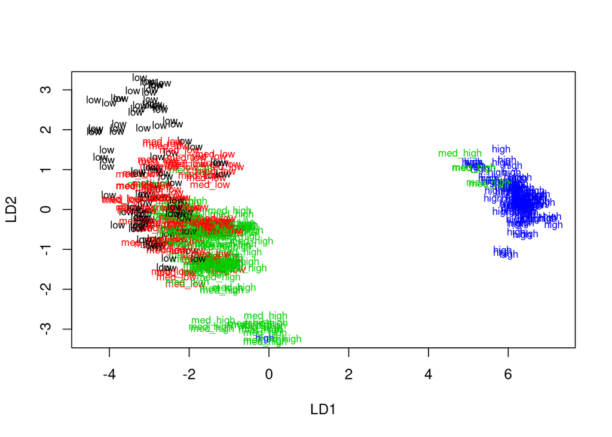

```r
plot(lda_model, dimen = 2, col = as.numeric(train$crime), pch = as.numeric(train$crime))
```

We’ll run a prediction model with LDA. Before that, the crime classes will be removed from the test set.

```r
# Save the correct classes from test data
correct_classes <- test$crime

# Remove the crime variable from test data
test <- dplyr::select(test, -crime)

# Predict with LDA
lda_predict <- predict(lda_model, newdata = test)
table(correct = correct_classes, predicted = lda_predict$class)
```

```
##           predicted
## correct    low med_low med_high high
##   low       16       7        1    0
##   med_low    8      17        6    0
##   med_high   0      11       13    1
##   high       0       0        0   22
```

## K-means algorithm

Next we’ll calculate distances between the observations. The dataset needs to be reloaded, after which we’ll scale the data and then calculate the distances.

```r
data("Boston")
Boston_rescaled <- scale(Boston)

# Euclidian distances
euc_Boston <- dist(Boston_rescaled)
#Manhattan distances
man_Boston <- dist(Boston_rescaled, method = "manhattan")

summary(euc_Boston)
```

```
##    Min. 1st Qu.  Median    Mean 3rd Qu.    Max.
##  0.1343  3.4625  4.8241  4.9111  6.1863 14.3970
```

```r
summary(man_Boston)
```

```
##    Min. 1st Qu.  Median    Mean 3rd Qu.    Max.
##  0.2662  8.4832 12.6090 13.5488 17.7568 48.8618
```

Manhattan distances tend to have higher units compared to Euclidian distances.

Next we’ll run K-means clustering and try to determine what is the best amount of centers for our data.

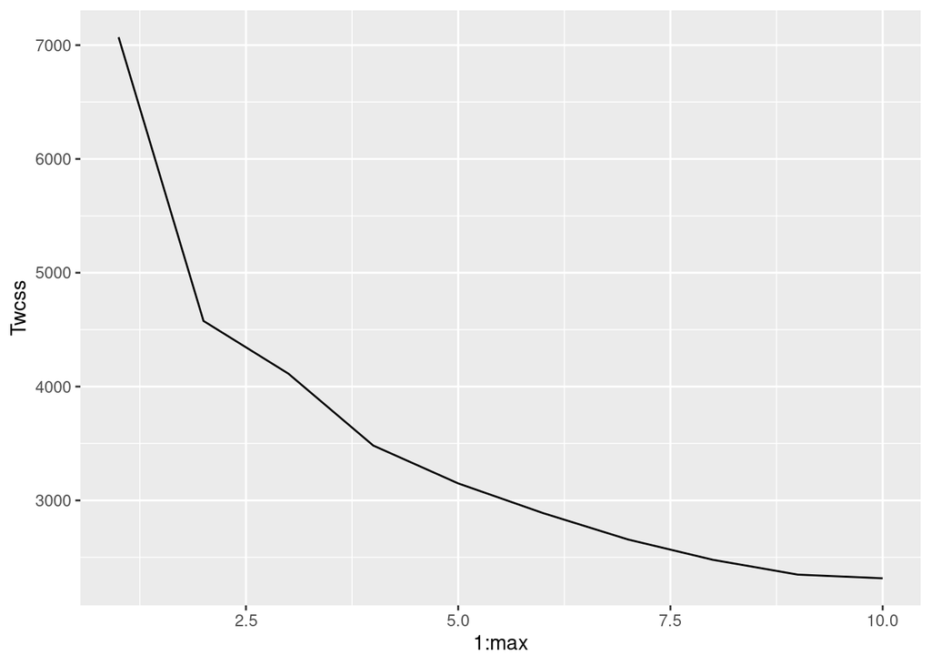

```r
# Define a maximum and calculate the total within sum of squares
max <- 10
Twcss <- sapply(1:max, function(k){kmeans(Boston_rescaled, k)$tot.withinss})

# Visualise
qplot(x = 1:max, y = Twcss, geom = 'line')
```

There’s a radical drop in the within cluster sum of squares at cluster 2. We’ll use this as an optimal number of clusters.

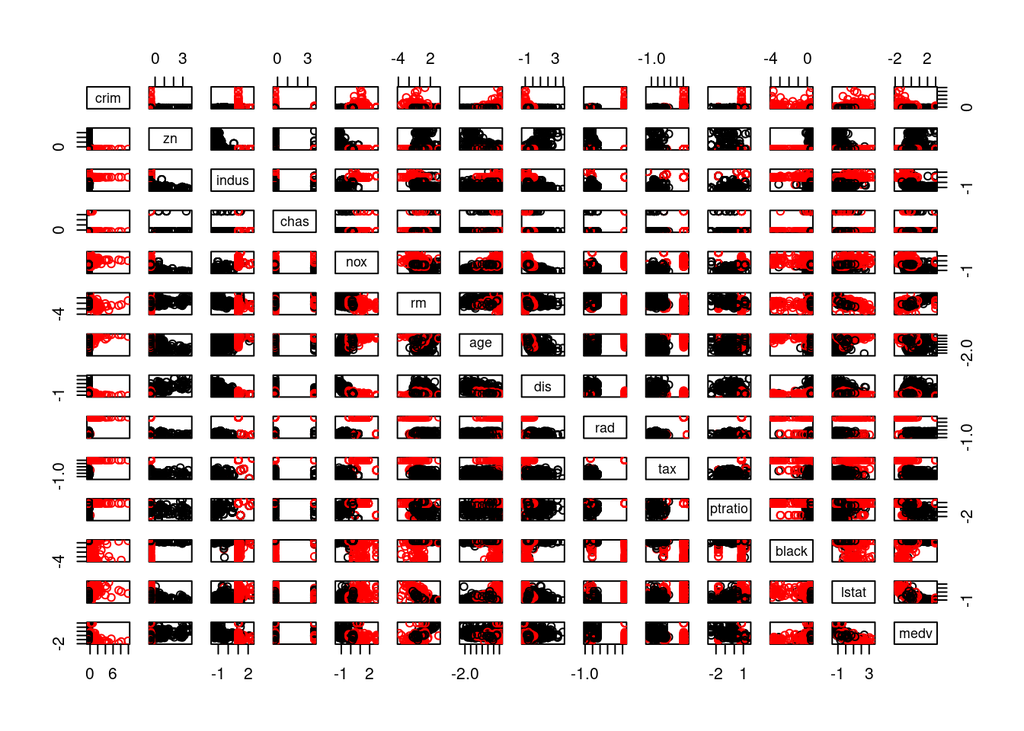

```r
# K-means clustering
km <- kmeans(Boston_rescaled, centers = 2)

# Plot the Boston dataset with clusters
pairs(Boston_rescaled, col = km$cluster)
```

Based on this, the two cluster optimum didn’t come out of nowhere. The two clusters seem to fall into their own groups in many cases like with variables crime, indus, nox, black, lstat, dis. A notable excpetion is the variable chas (Charles River dummy varaible) where the points are mixed when paired with e.g. age and pupil-teacher ratio (ptratio). We can’t, however, infer *what* exactly creates the dissimilarity. That’s a whole other exercise.